# 2025_reu_hypothesis_3_canopy

2025-07-21

# Hypothesis 3: Percent Live canopy will positively correlate with percent canker areas

- Variables: Canker area → Percent_live_canopy
- Mechanism: On the one hand, you expect canker area on trunk to impact percent live canopy, so the mechanism is actually that these should correlate. On the other hand we have seen numerous healthy trees in the canopy but highly diseased on the trunk and some trees with no canker spots but dead or fallen over; a priori prediction

# Data Import

**Click for data import info**

## Importing 2024 & 2025 Data

See the full code for the break down for the importing and cleaning open the documents of the same name. Or here: - [2024 cleaning code](https://rpubs.com/hankhelmers/cleaning_2024_health_form_data) and - [2025 cleaning code](https://rpubs.com/hankhelmers/cleaning_2025_health_form_data)

### Create the R files if needed.

Purl (or stitch) together R code from the markdown cleaning files. These stitched files are stored in ‘purl’ folder with the date of the code purled.

```r
# library(knitr)
#
# purl("cleaning_2024_health_form_data.Rmd",
#      output =
#        paste("purl/cleaning_2024_health_form_data",
#        Sys.Date(),".R"))
#
# purl("cleaning_2025_health_form_data.Rmd",
#      output =
#        paste("purl/cleaning_2025_health_form_data",
#        Sys.Date(),".R"))
```

### Run the R files to get cleaned data

Next, we can run those extracted R files to actually import and clean the data.

```r
## 2024 data
source(paste("purl/cleaning_2024_health_form_data", Sys.Date(), ".R"))

## 2025 data
source(paste("purl/cleaning_2025_health_form_data", Sys.Date(), ".R"))
```

### Combining 2024 and 2025 data along canker area & DBH

```r
library(dplyr)

# Add a 'year' column to each dataset to allow grouping/plotting by year
health_assess_2024 <- health_assess_2024 %>%
  mutate(year = 2024)

health_assess_2025 <- health_assess_2025 %>%
  mutate(year = 2025)

# Keep only the necessary columns for this hypothesis
sliced_2024 <- health_assess_2024 %>%
  select(year, dbh_cm, percent_live_canopy, base_canker_area, trunk_canker_area, seedling_y_n)

sliced_2025 <- health_assess_2025 %>%
  select(year, dbh_cm, percent_live_canopy, base_canker_area, trunk_canker_area, seedling_y_n)

# Combine the two data frames
combined_2024_2025 <- bind_rows(sliced_2024, sliced_2025)

# Fixing the Y, N, Yes, No discrepancies in combined
combined_2024_2025 <- combined_2024_2025 %>% mutate(seedling_y_n = if_else(seedling_y_n == "N", "No", seedling_y_n))
combined_2024_2025 <- combined_2024_2025 %>% mutate(seedling_y_n = if_else(seedling_y_n == "Y", "Yes", seedling_y_n))
```

# Setup of Analysis

This chunk defines a re-usable function to run a regression across multiple input datas.

```r
do_hypoth3_analysis <- function(data = combined_2024_2025, predictor, response, xlabel, ylabel, color = "black", color_points = "black") {
  # Model: Define linear model
  model <- lm(reformulate(predictor, response), data = data)
  coefs <- coef(model)
  r_squared <- summary(model)$r.squared
  p_value <- summary(model)$coefficients[2,4]   # pull p.value from linear regression model

  # Text: Create equation and R^2 text
  equation <- paste0("y = ", round(coefs[2], 2), "x + ", round(coefs[1], 2))
  r2_text <- paste0("italic(R)^2 == ", round(r_squared, 4))
  p_text <- paste0("p-value = ", round(p_value, 10))

  # Position: Get plotting ranges
  max_x <- max(data[[predictor]], na.rm = TRUE)

  max_y <- max(data[[response]], na.rm = TRUE)
  min_y <- min(data[[response]], na.rm = TRUE)
  range_y <- max_y - min_y

  # Annotate sample size near the bottom-right
  sample_size_y_position <- min_y + 0.08 * range_y

  # Annotate equation and r2 near the top-right
  p_y_position  <- max_y - 0.05 * range_y
  eq_y_position <- max_y - 0.12 * range_y
  r2_y_position <- max_y - 0.19 * range_y

  # PLOT ------------------------------------------------------
  ggplot(data, aes_string(x = predictor, y = response)) +
    # Points
    geom_point(aes_string(color = color_points)) +

    # Line of best fit
    geom_smooth(method = "lm", color = color) +

    # Axes Label & Theme
    labs(x = xlabel, y = ylabel) +  # Set the y-axis label
    theme(
      axis.title.x = element_text(color = color) # Change y-axis label color
    ) +

    # Samples size text
    annotate(
      "text",
      x = max_x,
      y = sample_size_y_position,
      label = paste("n = ", count(data)),
      hjust = 1,
      size = 6,
      color = "black"
    ) +

    # Equation and R^2 text
    annotate(
      "text",
      x = max_x,
      y = eq_y_position,
      label = equation,
      hjust = 1,
      size = 4,
      color = color
    ) +
    annotate(
      "text",
      x = max_x,
      y = r2_y_position,
      label = r2_text,
      hjust = 1,
      size = 4,
      color = color,
      parse = TRUE # Ensures that italics styling works
    ) +
    # P value text
    annotate(
      "text",
      x = max_x,
      y = p_y_position,
      label = p_text,
      hjust = 1,
      size = 4,
      color = color
    )
}
```

# Data Analysis

Here are the major delineations of questions across this hypotheses: * Done ? In-progress

# Hypothesis 3: Live canopy/severity of infection based on canopy will correlate with canker area

- What patterns of live canopy and canker area do we see overall? *
- What patterns of live canopy and canker area do we see across age classes? *
- What patterns of live canopy and canker area do we see across years? ?
- What patterns of live canopy and canker area do we see across sites? ?

## Patterns overall in 2025

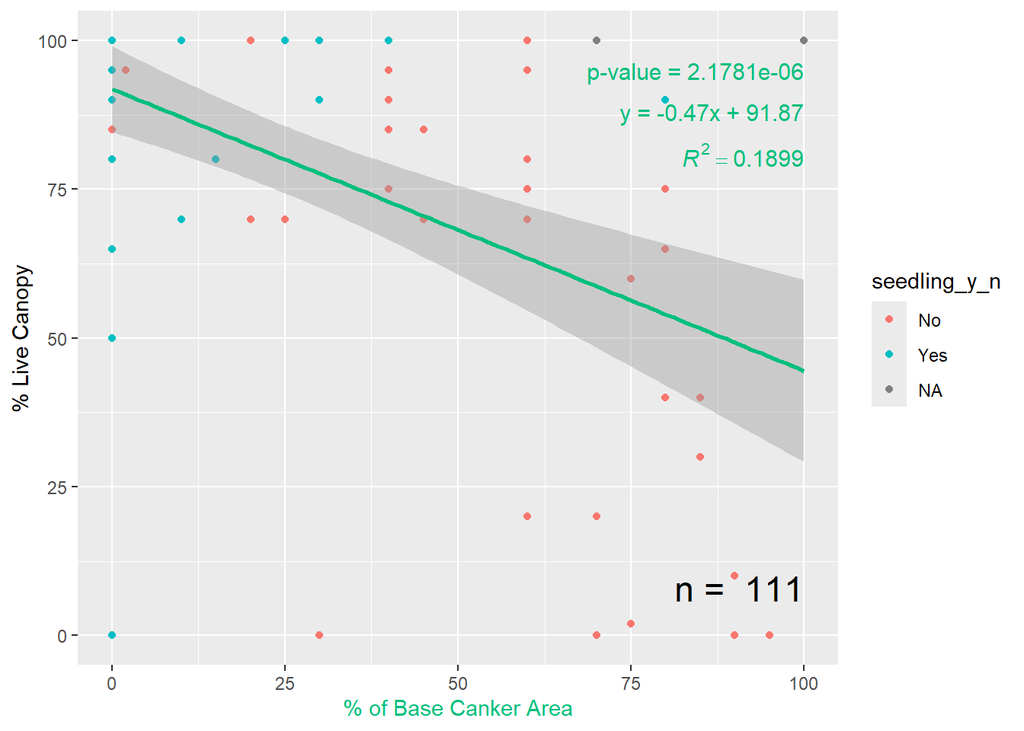

```r
library(scales)

hex <- hue_pal()(5)

patterns_across_2025_base <- do_hypoth3_analysis(
  data = health_assess_2025,
  predictor = "base_canker_area",
  response = "percent_live_canopy",
  xlabel = "% of Base Canker Area",
  ylabel = "% Live Canopy",
  color = hex[3],
  color_points = "seedling_y_n"
)
patterns_across_2025_base
```

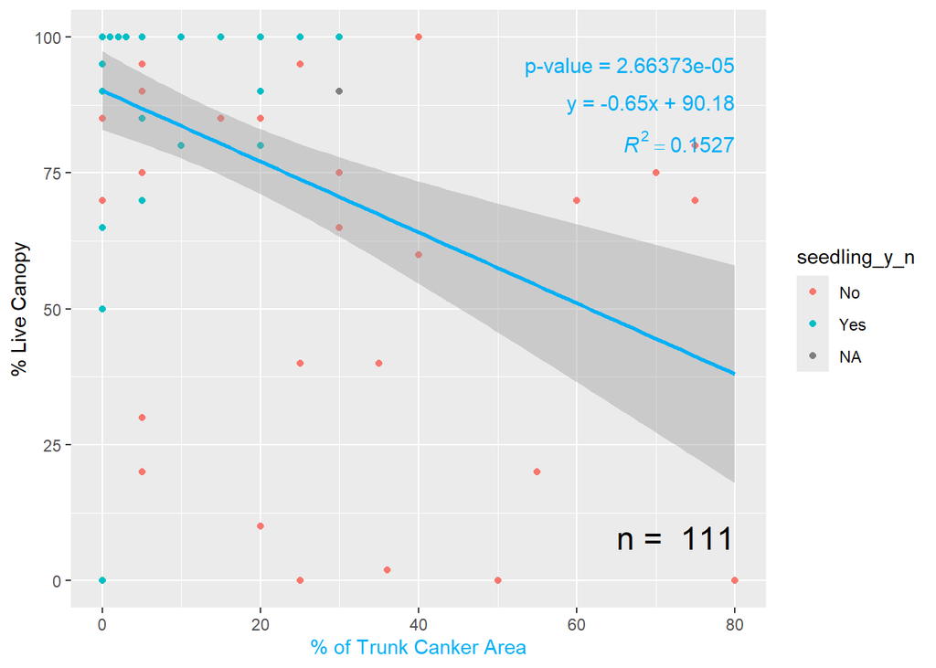

```r
patterns_across_2025_trunk <- do_hypoth3_analysis(
  data = health_assess_2025,
  predictor = "trunk_canker_area",
  response = "percent_live_canopy",
  xlabel = "% of Trunk Canker Area",
  ylabel = "% Live Canopy",
  color = hex[4],
  color_points = "seedling_y_n"
)
patterns_across_2025_trunk
```

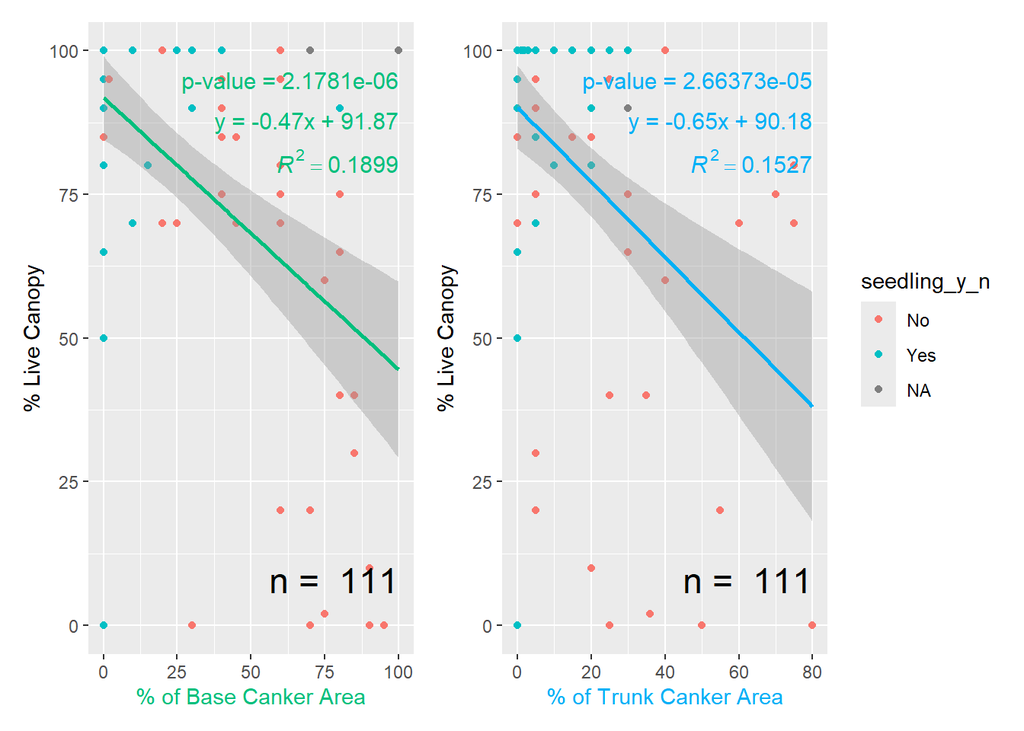

```r
library(patchwork)

(patterns_across_2025_base + patterns_across_2025_trunk) + plot_layout(guide = "collect")
```

## Patterns across seedlings versus adults

### Seedlings

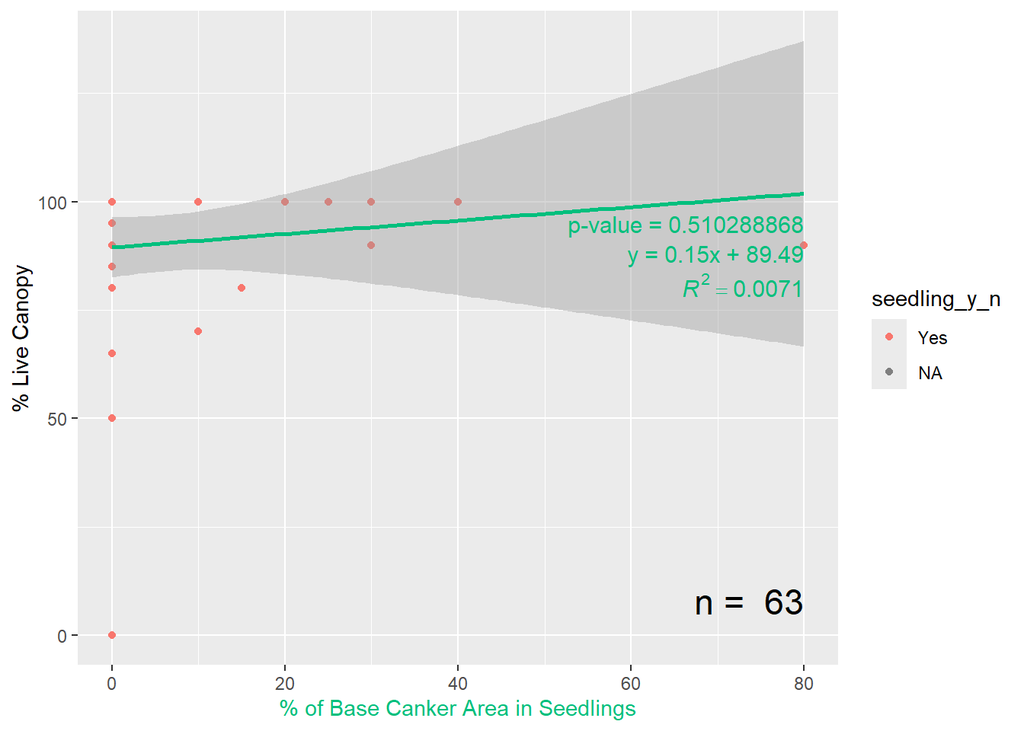

```r
library(scales)

hex <- hue_pal()(5)

seedlings_combined <- health_assess_2025 %>% filter(is.na(dbh_cm))

patterns_across_seedlings_base <- do_hypoth3_analysis(
  data = seedlings_combined,
  predictor = "base_canker_area",
  response = "percent_live_canopy",
  xlabel = "% of Base Canker Area in Seedlings",
  ylabel = "% Live Canopy",
  color = hex[3],
  color_points = "seedling_y_n"
)
patterns_across_seedlings_base
```

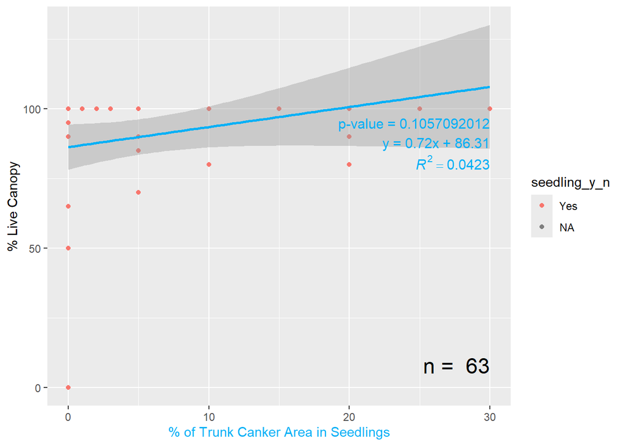

```r
patterns_across_seedlings_trunk <- do_hypoth3_analysis(
  data = seedlings_combined,
  predictor = "trunk_canker_area",
  response = "percent_live_canopy",
  xlabel = "% of Trunk Canker Area in Seedlings",
  ylabel = "% Live Canopy",
  color = hex[4],
  color_points = "seedling_y_n"
)
patterns_across_seedlings_trunk
```

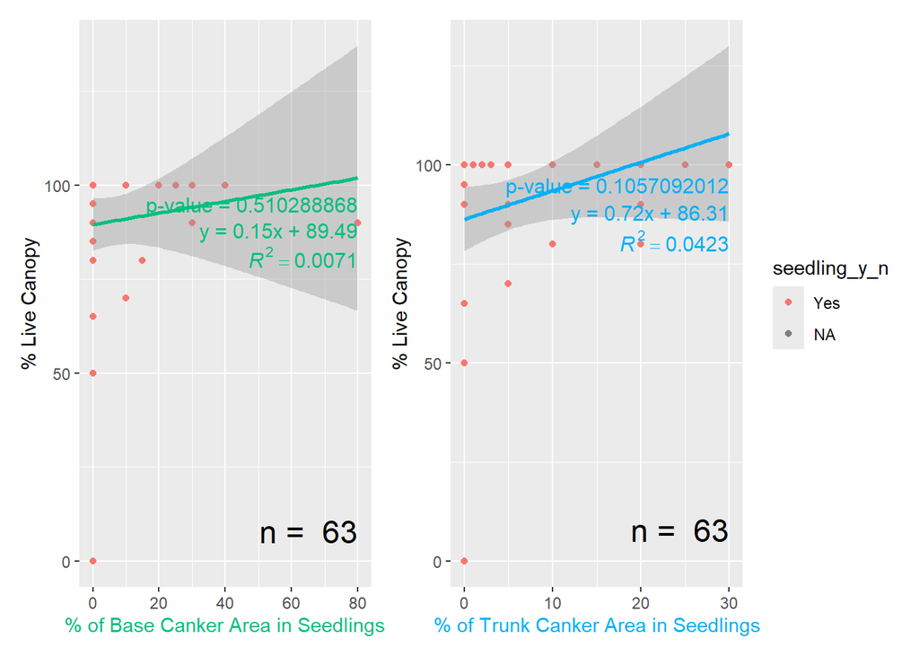

```r
library(patchwork)

seedlings_2025 <- (patterns_across_seedlings_base + patterns_across_seedlings_trunk) + plot_layout(guide = "collect")
seedlings_2025
```